# Correlation and Regression

Emma Rand

[figure not shown]

Emma Rand. (2022). Data Analysis in R (BIO00017C) 2020: 2022 (v1.1). Zenodo. https://doi.org/10.5281/zenodo.6359475

# Introduction

## Session overview

In this workshop you will get practice in applying, interpreting and reporting correlation and regression.

## Learning Outcomes

By actively following the materials and carrying out the independent study before and after the contact hours the successful student will be able to:

- Explain the principles of correlation and of regression and know when each can be applied (MLO 1)
- Select, appropriately correlation and regression (MLO 2)
- Apply and interpret a correlation in R (MLO 3 and 4)
- Appreciate the difference between statistical significance and biological significance (MLO 1 and 4)
- Apply and interpret a simple linear regression in R (MLO 3 and 4)
- Evaluate whether the assumptions of regression are met (MLO 2)
- Summarise and illustrate with appropriate R figures test results scientifically (MLO 3 and 4)

## Philosophy

Workshops are not a test. It is expected that you often don’t know how to start, make a lot of mistakes and need help. Do not be put off and don’t let what you can not do interfere with what you can do. You will benefit from collaborating with others and/or discussing your results. It is expected that you are familiar with independent study content before the workshop. However, you need not remember or understand every detail as the workshop should build and consolidate your understanding. You may wish to refer to the independent study materials for reference.

Materials are indexed here: https://3mmarand.github.io/BIO00017C-Data-Analysis-in-R-2020/

## Key

These four symbols are used at the beginning of each instruction so you know where to carry out the instruction.

is something you need to do on your computer. It may be opening programs or documents or locating a file.

is something you should do in RStudio. It will often be typing a command or using the menus but might also be creating folders, locating or moving files.

is something you should do in your browser on the internet. It may be searching for information, going to the VLE or downloading a file.

is question for you to think about an answer. You will usually want to record your answers in your script for future reference.

[figure not shown]

Artwork by Allison Horst

# Getting started

Start RStudio from the Start menu.

Make an RStudio project for this workshop by clicking on the drop-down menu on top right where it says Project: (None) and choosing New Project and then New Directory, then New Project. Navigate to the “data-analysis-in-r” folder. Name the RStudio Project ‘workshop7’.

On the Files tab make two folders `data-raw` and `figures`

Make a new script then save it with a name like analysis.R to carry out the rest of the work.

Load the `tidyverse`:

```r
library(tidyverse)
```

# Exercises

## Pearson’s Correlation

The data given in height.txt are the heights of eleven brother and sister pairs.

Save a copy of height.txt to your `data-raw` folder and import it.

**Top Tip**

Did you know you can also read files directly from the internet instead of saving it first? `read_table("https://3mmarand.github.io/BIO00017C-Data-Analysis-in-R-2020/data/height.txt")`

### Exploring

What type of variables are ‘brother’ and ‘sister’? What are the implications for the test?

Do a quick plot of the data. We don’t have a causal relationship here so either variable can go on the *x*-axis.

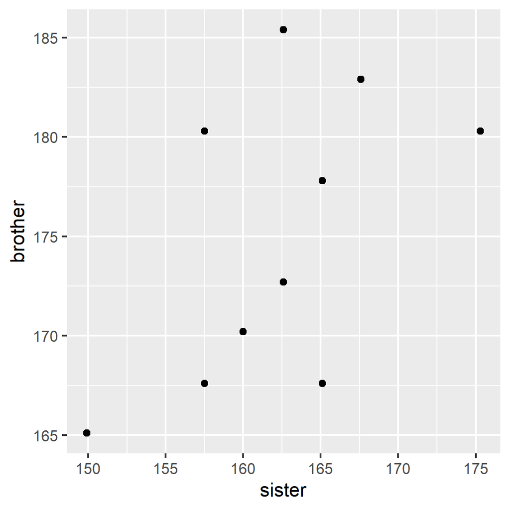

```r
ggplot(height, aes(x = sister, y = brother) ) +
  geom_point()
```

Remembering that one of the assumptions for parametric correlation is that any correlation should be linear, what do you conclude from the plot?

### Applying, interpreting and reporting

We will do a parametric correlation in any case.

We can carry out a Pearson’s product moment correlation with:

```r
cor.test(data = height, ~ brother + sister, method = "pearson")
```

```
##
##  Pearson's product-moment correlation
##
## data:  brother and sister
## t = 2.0157, df = 9, p-value = 0.07464
## alternative hypothesis: true correlation is not equal to 0
## 95 percent confidence interval:
##  -0.06336505  0.86739285
## sample estimates:
##       cor
## 0.5577091
```

Notice that were are not using the `response ~ explanatory` form here because this is not a causal relationship.

Pearson is the default method, therefore we could omit `method = "pearson"`.

What do you conclude from the test?

### Illustrating

Create a better figure for our data using:

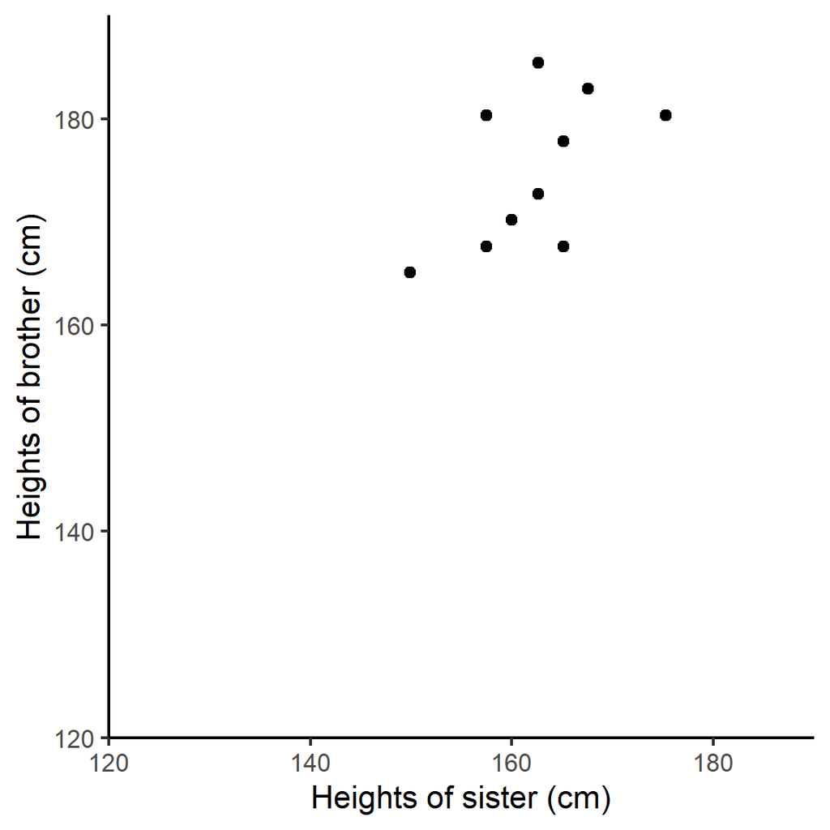

```r
fig1 <- ggplot(height, aes(x = sister, y = brother)) +
  geom_point() +
  scale_x_continuous(name = "Heights of sister (cm)",
                     limits = c(120, 190),
                     expand = c(0, 0)) +
  scale_y_continuous(name = "Heights of brother (cm)",
                     limits = c(120, 190),
                     expand = c(0, 0)) +
   theme_classic()

fig1
```

Figure 1. Correlation in height between brothers and sisters.

Use `ggsave()` to save your figure to file in your `figures` folder.

## Effect of sample size on correlation

Now we will explore the effect of sample size on the value of the correlation coefficient and its significance.

Create a dataset with twice the number of observations and examine it like this:

```r
height2 <- rbind(height, height)
View(height2)
```

Each pair of values will appear twice.

Now repeat the correlation with height2

What do you conclude? What does this tell you about the sensitivity of correlation to sample size?

## Spearman’s rank Correlation

Since our brother-sister dataset is so small we might very reasonably have chosen to do a non-parametric correlation. The same function is used but we specify a different value for the `method` argument.

Carry out a Spearman’s rank correlation:

```r
cor.test(data = height, ~ brother + sister, method = "spearman")
```

```
##
##  Spearman's rank correlation rho
##
## data:  brother and sister
## S = 109.74, p-value = 0.1163
## alternative hypothesis: true rho is not equal to 0
## sample estimates:
##       rho
## 0.5011722
```

What do you conclude?

## Linear Regression

The data in plant.xlsx is a set of observations of plant growth over two months. The researchers planted the seeds and harvested, dried and weighed a plant each day from day 10 so all the data points are independent of each other.

```r
library(readxl)
```

Save a copy of plant.xlsx to your `data-raw` folder and import it.

What type of variables do you have? Which is the response and which is the explanatory? What is the null hypothesis?

### Exploring

Do a quick plot of the data (as shown)

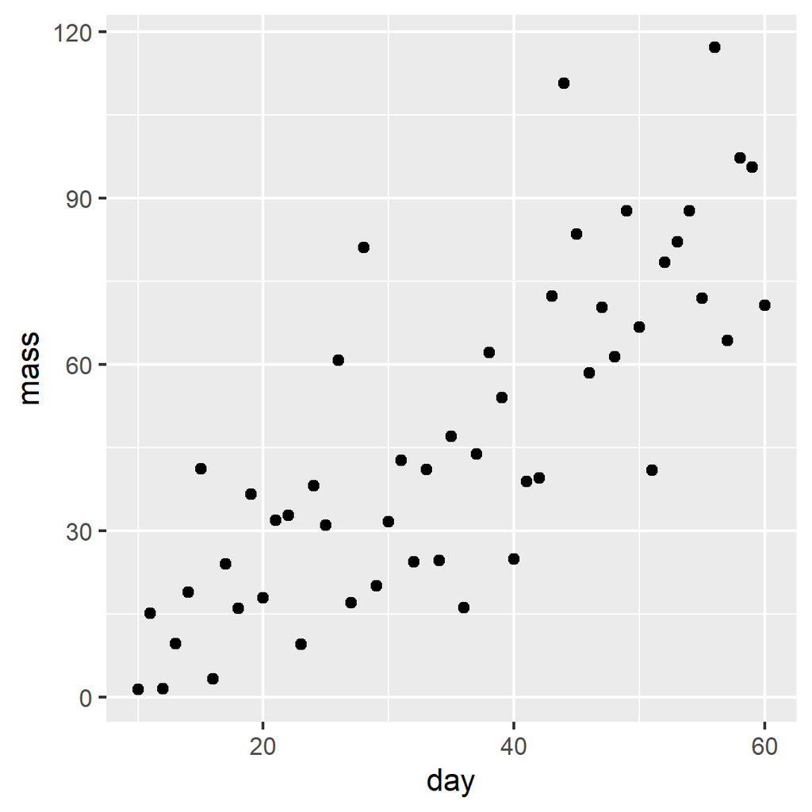

What are the assumptions of linear regression? Do these seem to be met?

### Applying, interpreting and reporting

We now carry out a regression assigning the result of the `lm()` procedure to a variable and examining it with `summary()`.

```r
mod <- lm(data = plant, mass ~ day)
summary(mod)
```

```
##
## Call:
## lm(formula = mass ~ day, data = plant)
##
## Residuals:
##     Min      1Q  Median      3Q     Max
## -32.810 -11.253  -0.408   9.075  48.869
##
## Coefficients:
##             Estimate Std. Error t value Pr(>|t|)
## (Intercept)  -8.6834     6.4729  -1.342    0.186
## day           1.6026     0.1705   9.401  1.5e-12 ***
## ---
## Signif. codes:  0 '***' 0.001 '**' 0.01 '*' 0.05 '.' 0.1 ' ' 1
##
## Residual standard error: 17.92 on 49 degrees of freedom
## Multiple R-squared:  0.6433, Adjusted R-squared:  0.636
## F-statistic: 88.37 on 1 and 49 DF,  p-value: 1.503e-12
```

The Estimates in the Coefficients table give the intercept (first line) and the slope (second line) of the best fitting straight line. The *p*-values in the same table are tests of whether that coefficient is different from zero.

The *F* value and *p*-value in the last line are a test of whether the model as a whole explains a significant amount of variation in the dependent variable. For a single linear regression this is exactly equivalent to the test of the slope against zero.

What is the equation of the line? What do you conclude from the analysis?

Does the line go through (0,0)?

What percentage of variation is explained by the line?

### Checking selection

Check the assumptions of the test by looking at the distribution of the ‘residuals’.

### Illustrating

We want a figure with the points and a best fitting straight line.

Create a figure with using both `geom_point()` and `geom_smooth()`

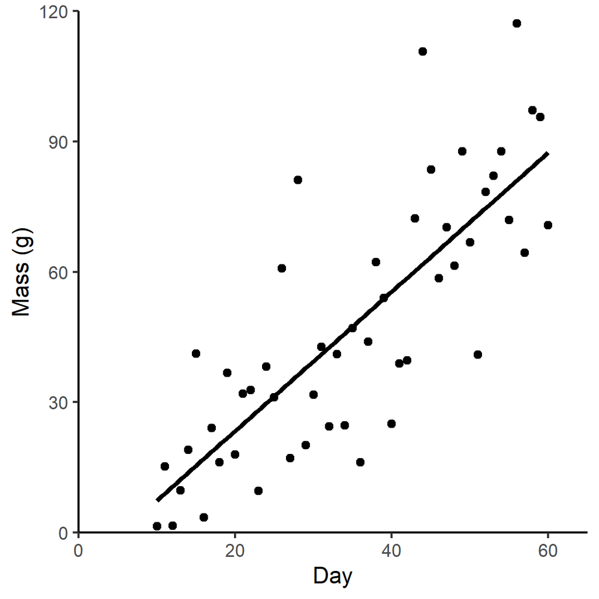

```r
ggplot(plant, aes(x = day, y = mass)) +
  geom_point() +
  geom_smooth(method = lm,
              se = FALSE,
              colour = "black") +
  scale_x_continuous(name = "Day",
                     limits = c(0, 65),
                     expand = c(0,0)) +
  scale_y_continuous(name = "Mass (g)",
                     limits = c(0, 120),
                     expand = c(0,0)) +
  theme_classic()
```

Figure 2. The relationship between day since planting and mass.

Can you workout how to add the equation of the line to the figure like this?

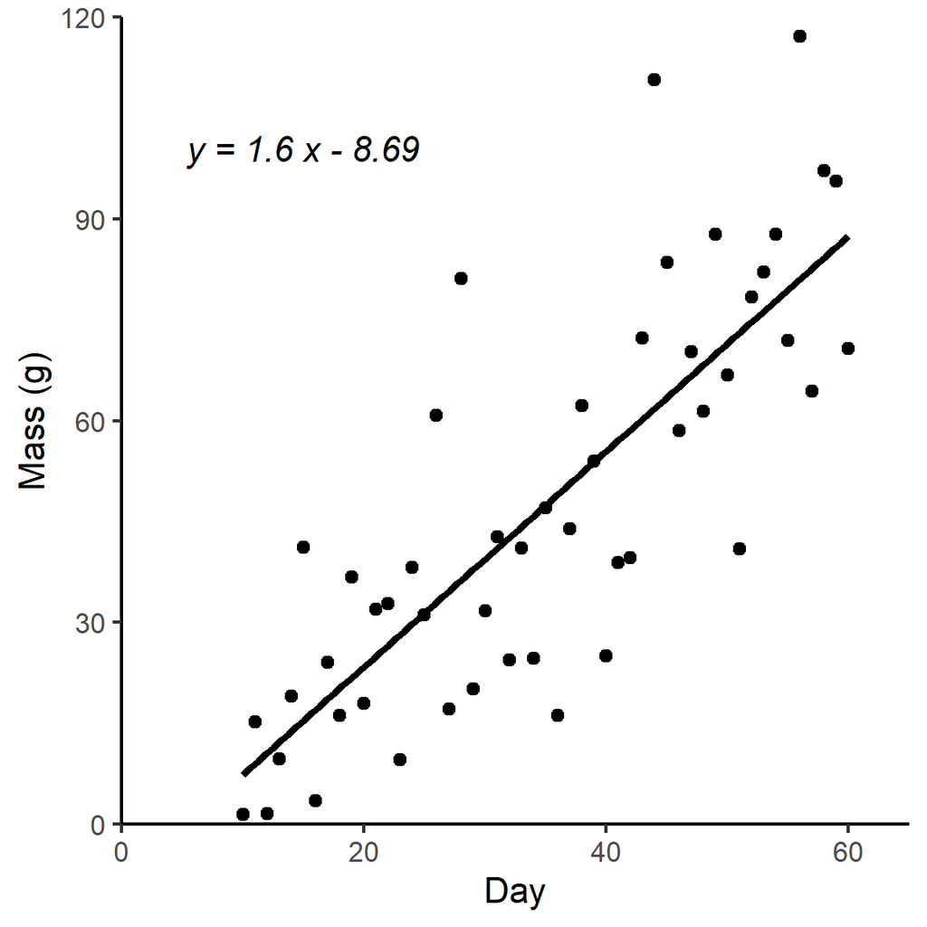

Save your figure to your `figures` folder.

Close your project, locate the folder Explorer/Finder and zip it by doing: Right click, Send to | Compressed (zipped) folder. Then email it to your friend and check they can open your unzipped project and run your code without having to chang anything.

# Independent study

Decide how to analyse the following data sets. In each, use an RStudio project with logical directory structure. Organise and comment your code well and include your reasoning and decisions. Write your conclusions as comments in a form suitable for including in a report. Create and save an appropriate figure.

## 1 Effect of anxiety status and sporting performance

The data in sprint.txt are from an investigation of the effect of anxiety status and sporting performance. A group of 40 100m sprinters undertook a psychometric test to measure their anxiety shortly before competing. The data are their anxiety scores and the 100m times achieved. What you do conclude from these data?

## 2. Juvenile hormone in stag beetles

The concentration of juvenile hormone in stag beetles is known to influence mandible growth. Groups of stag beetles were injected with different concentrations of juvenile hormone (arbitrary units) and their average mandible size (mm) determined. The experimenters planned to analyse their data with regression. The data are in stag.txt

# The Code files

These contain all the code needed in the workshop even where it is not visible on the webpage.

Rmd file The Rmd file is the file I use to compile the practical. Rmd stands for R markdown. It allows R code and ordinary text to be interweaved to produce well-formatted reports including webpages. If you right-click on the link and choose Save-As, you will be able to open the Rmd file in RStudio. Alternatively, [View in Browser](https://github.com/3mmaRand/BIO00017C-Data-Analysis-in-R-2020/blob/main/workshops/07CorrelationAndRegression.Rmd).

Plain script file This is plain script (.R) version of the practical generated from the Rmd. Again, you can save this and open it RStudio. Alternatively, [View in Browser](https://github.com/3mmaRand/BIO00017C-Data-Analysis-in-R-2020/blob/main/scripts/07CorrelationAndRegression.R).

Pages made with `rmarkdown` (Allaire Xie, et al., 2019a; Xie Allaire, et al., 2018a), `kableExtra` (Zhu, 2019a), `RefManager` (McLean, 2014)

# References

Allaire, J., Y. Xie, et al. (2019a). *rmarkdown: Dynamic Documents for R*. R package version 1.16. URL: https://github.com/rstudio/rmarkdown.

McLean, M. W. (2014). *Straightforward Bibliography Management in R Using the RefManager Package*. arXiv: 1403.2036 [cs.DL]. URL: https://arxiv.org/abs/1403.2036.

Xie, Y., J. Allaire, et al. (2018a). *R Markdown: The Definitive Guide*. ISBN 9781138359338. Boca Raton, Florida: Chapman and Hall/CRC. URL: https://bookdown.org/yihui/rmarkdown.

Zhu, H. (2019a). *kableExtra: Construct Complex Table with ‘kable’ and Pipe Syntax*. R package version 1.1.0. URL: https://CRAN.R-project.org/package=kableExtra.

# Please cite as:

Emma Rand. (2022). Data Analysis in R (BIO00017C) 2020: 2022 (v1.1). Zenodo. https://doi.org/10.5281/zenodo.6359475